# Test on JupyterLab Slide

## Info

- official document: https://jupyterlab.readthedocs.io/en/latest/user/export.html#reveal-js-slides
- the RISE extension of jupyter notebook has yet not worked for jupyterlab, see this [issue](https://github.com/damianavila/RISE/issues/270)

## It seems to be a good idea to add a line after slide titles

- more clear when writing
- more clear when showing

## Test markdown effects

some text ...

try **mark down** see *if* it works

a link

## Some Code

- Put text and code in the same slide by simply setting Slide Type of other chunks to `-`

```python
df = pd.util.testing.makeDataFrame().reset_index(drop=True)
df.head()
```

|  | A | B | C | D |
| --- | --- | --- | --- | --- |
| 0 | -0.55 | 0.75 | -0.11 | 0.11 |
| 1 | 1.17 | 0.49 | -0.98 | 0.36 |
| 2 | 0.62 | 0.75 | -0.62 | 0.17 |
| 3 | 1.11 | 0.94 | -1.20 | 0.36 |
| 4 | 0.94 | -0.17 | 0.57 | 0.06 |

add some text in bottom

- Alternatively you can set Slide Type to `Sub-Slide` (arrow down) if the code or the result needs more space

```python
pd.concat([df.tail(10), df.tail(10)], axis=1)
```

|  | A | B | C | D | A | B | C | D |
| --- | --- | --- | --- | --- | --- | --- | --- | --- |
| 20 | -0.80 | 0.73 | -0.04 | -0.67 | -0.80 | 0.73 | -0.04 | -0.67 |
| 21 | 1.55 | 0.35 | -0.90 | 0.64 | 1.55 | 0.35 | -0.90 | 0.64 |
| 22 | 0.21 | -0.87 | -0.09 | -0.07 | 0.21 | -0.87 | -0.09 | -0.07 |
| 23 | 1.52 | 1.37 | -0.84 | 0.47 | 1.52 | 1.37 | -0.84 | 0.47 |
| 24 | -1.02 | 0.28 | 1.67 | 0.54 | -1.02 | 0.28 | 1.67 | 0.54 |
| 25 | 0.04 | -0.37 | 1.60 | 0.82 | 0.04 | -0.37 | 1.60 | 0.82 |
| 26 | 0.22 | -0.75 | 0.25 | 0.00 | 0.22 | -0.75 | 0.25 | 0.00 |
| 27 | -0.17 | 0.79 | 0.45 | -0.32 | -0.17 | 0.79 | 0.45 | -0.32 |
| 28 | 0.99 | -0.44 | -0.14 | 0.19 | 0.99 | -0.44 | -0.14 | 0.19 |
| 29 | -1.43 | -0.72 | 2.38 | 0.11 | -1.43 | -0.72 | 2.38 | 0.11 |

## Some Plot

- It is also cool to set Slide Type to `Fragment` (again arrow down)

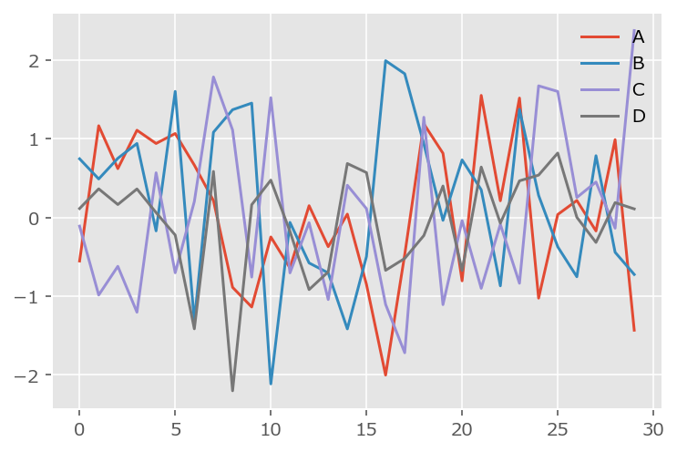

```python
df.plot();
```

- say something more

## Convert Notes:

- use `!jupyter nbconvert test.ipynb --to slides`
  - this convert the file in current dir and cover the past one
- if you want to suppres the code input, see this [issue](https://github.com/jupyterlab/jupyterlab/issues/4100)
  - but it need use terminal to nbconvert the slides
  - `jupyter nbconvert presentation.ipynb --config my_slide_config.py`

## Alternative:

- You can use Rstudio and Rmarkdown to produce python slides as well